# Simple Linear Regression

**Two Main Objectives of Regression**

**1:- Establish if there is a relationship between two variables.**

```
=> More Specifically.to find if there is statistically significant relationship betwwen the two.
```

**2:-Forcast new observation.**

# Variable's

**Two Types of Variables:**

**1:-Dependant Variable**

**2:-Independant Vriable**

**1:- Dependant Variable:**

```
=>These are the variables whose value we want to explain or forcast.

=>It's values depend on something else

=>We denote it as "y"
```

**2:- Independant variable:**

```
=>This is the variable that explain the other one

=>It's values are independant

=>We donte it as "x"
```

# A Linear Equation

**we call it linear because the equation represent a straight line in a Bi-dimensional plot.**

```
          y=a+(b*x)...................... (Eq1)
```

but, the data in real world is gonna be series of x and y observations. that on avrage may follow linear path, thats why we use Linear Regression model to represent them. but the line not always gonna intercept the points, there are gonna be errors. and that we can measure, which are the distance between dots and the actual linear regression, so the Linear Regression is gonna do to draw a line which will minimise the errors. our linear regression model must include this error aspect in it

so,

```
         y=a+(b*x)+E......................(Eq2)


    where,
          y= Depnedant Variable
          x= Independant Variable
          a= Is the constant or intercept
          b= Is x's Coefficient
          E= Is the error term
```

**PROBLEM:**

problem is to investigate the Linear relationship betweeen Years of Experience and Salary of employee.

```python
import pandas as pd
import numpy as np
df=pd.read_csv("C:\\Users\\Aniket\\Desktop\\Salary_Data.csv") #imported the data from pc
df
```

|  | YearsExperience | Salary |
| --- | --- | --- |
| 0 | 1.1 | 39343.0 |
| 1 | 1.3 | 46205.0 |
| 2 | 1.5 | 37731.0 |
| 3 | 2.0 | 43525.0 |
| 4 | 2.2 | 39891.0 |
| 5 | 2.9 | 56642.0 |
| 6 | 3.0 | 60150.0 |
| 7 | 3.2 | 54445.0 |
| 8 | 3.2 | 64445.0 |
| 9 | 3.7 | 57189.0 |
| 10 | 3.9 | 63218.0 |
| 11 | 4.0 | 55794.0 |
| 12 | 4.0 | 56957.0 |
| 13 | 4.1 | 57081.0 |
| 14 | 4.5 | 61111.0 |
| 15 | 4.9 | 67938.0 |
| 16 | 5.1 | 66029.0 |
| 17 | 5.3 | 83088.0 |
| 18 | 5.9 | 81363.0 |
| 19 | 6.0 | 93940.0 |
| 20 | 6.8 | 91738.0 |
| 21 | 7.1 | 98273.0 |
| 22 | 7.9 | 101302.0 |
| 23 | 8.2 | 113812.0 |
| 24 | 8.7 | 109431.0 |
| 25 | 9.0 | 105582.0 |
| 26 | 9.5 | 116969.0 |
| 27 | 9.6 | 112635.0 |
| 28 | 10.3 | 122391.0 |
| 29 | 10.5 | 121872.0 |

# The head() Function

In Python we have pandas library in that there is a head() function. we use head() function to display the top five rows of DataFrame

```python
df.head()
```

|  | YearsExperience | Salary |
| --- | --- | --- |
| 0 | 1.1 | 39343.0 |
| 1 | 1.3 | 46205.0 |
| 2 | 1.5 | 37731.0 |
| 3 | 2.0 | 43525.0 |
| 4 | 2.2 | 39891.0 |

# The Shape Attribute

In pandas we have shape attribute stores the number of rows and number of columns as a tuple of a DataFrame.

```python
print(df.shape)
```

```
(30, 2)
```

# The info() Function

In pandas we have info() function that use to obtain the information about the DataFrame

```python
print(df.info())
```

```
<class 'pandas.core.frame.DataFrame'>
RangeIndex: 30 entries, 0 to 29
Data columns (total 2 columns):
 #   Column           Non-Null Count  Dtype
---  ------           --------------  -----
 0   YearsExperience  30 non-null     float64
 1   Salary           30 non-null     float64
dtypes: float64(2)
memory usage: 608.0 bytes
None
```

# Converting DataFrame

**To prform the operation maually or from a scratch we can't perform on a DataFrame or it's complicated procedure so we convert it into numpy arrays**

there are two Syntax to convert pandas DataFrame into numpy arrays they are as follows:-

**basic step**:- import numpy (or) import numpy as np, any of one that you prefer.

**Syntax 1:-** varname=VarOriginal[['object']].to_numpy()

**Syntax 2:-** varname=VarOriginal[['object']].values

here,

```
  varname= new variable name where you want to put that objects value

VarOriginal= variable name of DataFRame

   object= Dataframe object that you want to convert
```

**we gonna use 1st Syntax:-**

```python
x=df[['YearsExperience']].to_numpy()
print(x)
```

```
[[ 1.1]
 [ 1.3]
 [ 1.5]
 [ 2. ]
 [ 2.2]
 [ 2.9]
 [ 3. ]
 [ 3.2]
 [ 3.2]
 [ 3.7]
 [ 3.9]
 [ 4. ]
 [ 4. ]
 [ 4.1]
 [ 4.5]
 [ 4.9]
 [ 5.1]
 [ 5.3]
 [ 5.9]
 [ 6. ]
 [ 6.8]
 [ 7.1]
 [ 7.9]
 [ 8.2]
 [ 8.7]
 [ 9. ]
 [ 9.5]
 [ 9.6]
 [10.3]
 [10.5]]
```

```python
y=df[['Salary']].to_numpy()
print(y)
```

```
[[ 39343.]
 [ 46205.]
 [ 37731.]
 [ 43525.]
 [ 39891.]
 [ 56642.]
 [ 60150.]
 [ 54445.]
 [ 64445.]
 [ 57189.]
 [ 63218.]
 [ 55794.]
 [ 56957.]
 [ 57081.]
 [ 61111.]
 [ 67938.]
 [ 66029.]
 [ 83088.]
 [ 81363.]
 [ 93940.]
 [ 91738.]
 [ 98273.]
 [101302.]
 [113812.]
 [109431.]
 [105582.]
 [116969.]
 [112635.]
 [122391.]
 [121872.]]
```

# Calculation to Find Variance

**Formula of Variance:-** **variance=1/n∑(xi-xbar)^2** ............... in general

**xbar=(Sumation(x)/n)**

**ybar=(Sumation(y)/n)**

so if calculate seprately for x and y it's gonna be lengthy program,time consuming and its gonna take lots of memory space,that's if we with traditional way of programming.

So we gonna use User Defined Functions way of programming, merits of this type is it goona reduce, Time,Memory Space,easy to write the code,and we can use it anywhere in program

So here we defined function called mean(), for mean of some number called 'n'.you can use any word its totally upon you. in genrally what is mean, mean is sum of a total values inside function orlist or variable devided by it's total length

So we created the logic for that and return its value to main program, so anywhere you want to use just call the function

```python
def mean(n):
    m=(sum(n))/(len(n))
    return m
xbar=mean(x)
ybar=mean(y)
print(xbar)
print(ybar)
```

```
[5.31333333]
[76003.]
```

# varience of x and y

**variance of x:- 1/n∑(xi-xbar)^2**

where,

```
  n= len(x)
```

**variance of y:- 1/n∑(yi-ybar)^2**

where,

```
   n=len(y)
```

**here,**

```
   we created two empty lists x1 and y1( two ways of creating empty list: 1:-variable_name=[], 2:-variable_name=list())
   after creating empty list, wrote the logic for (x-xbar)^2 and append (adding values) those values to empty list that
   created list of every element from (x- xbar)^2 that is list x1

   after that calulated the sum of all the values from list x1 put it into variable name Sum_xDiffrence
   to add all values from list we use predefined function called sum(), this function add all values from list

   then we got Sum_xDiffrencen i.e ∑(xi-xbar)^2

   repeat all the steps to find ∑(yi-ybar)^2 i.e Sum_yDiffrence
```

```python
x1=[]
y1=[]
for val in x:
    x_Diffrence=((val)-(xbar))**2
    x1.append(x_Diffrence)
for val in y:
    y_Diffrence=((val)-(ybar))**2
    y1.append(y_Diffrence)
Sum_xDiffrence=sum(x1)
Sum_yDiffrence=sum(y1)
print(Sum_xDiffrence)
print(Sum_yDiffrence)
```

```
[233.55466667]
[2.17949779e+10]
```

# Here we calculate Veriance of X and Y

**veriance of x=1/(len(x))∑(xi-xbar)^2**

**veriance of y=1/(len(y))∑(yi-ybar)^2**

here,

```
 We defined user define function to calculate veriance

where,

      'D' represents ∑(xi-xbar)^2 or ∑(yi-ybar)^2 i.e Sum_xDiffrence or Sum_yDiffrence
      'n' represents len(x) or len(y)
```

```python
def var(D,n):
    Var=D/n
    return Var
varX=var(Sum_xDiffrence,len(x))
print(varX)
varY=var(Sum_yDiffrence,len(y))
print(varY)
```

```
[7.78515556]
[7.26499262e+08]
```

# To find Covariance

**The formula of covariance is 1/n∑((xi-xbar)(yi-ybar)**

here,

```
 we created the empty lists of cv1 and cv2 to store the values of (xi-xbar) and (yi-ybar) respectively. then define the
 logic to perform operation store that value into x_Diff and y_Diff respectively.then append the result to corrosponding
 empty lists.
```

after that operation we got two list cv1 and cv2 i.e (xi-xbar) and (yi-ybar)

```python
cv1=[]
cv2=[]
for val in x:
    x_Diff=((val)-(xbar))
    cv1.append(x_Diff)
for val in y:
    y_Diff=((val)-(ybar))
    cv2.append(y_Diff)
```

# Multiplication of two lists

In previous step we got two list i.e (cv1,cv2) those represents (xi-xbar) and (yi-ybar)

But according to formula of Covariance we need multiplication of those valuse.

for that we need to multiply those two lists,So we gonna do that in this step.

We write a logic to perform the operation

i.e in this, we simply run a loop and append to the new list the product of the both list elements at similar index till we reach the end of the list

So we got the 'xy'

```
               xy= product of (xi-xbar)*(yi-ybar)
```

```python
xy=[cv1[i]*cv2[i] for i in range(0,(len(cv2))) ]
```

**After the multiplication we need to find the ∑(xy)**

we used the inbuilt function called sum() that gave us ∑(xi-xbar)(yi-ybar) i.e represented by "xy_Sumation"

```python
xy_Sumation=sum(xy)
print(xy_Sumation)
```

```
[2207082.8]
```

# Calculating Covariance

**The Formula of Covariance is:-1/n∑((xi-xbar)(yi-ybar))**

According to formula we get:-

```python
Coverihance=xy_Sumation/(len(xy))
print(Coverihance)
```

```
[73569.42666667]
```

# Finding the values of a and b

**Formula of b:- Covariance/variance(x)**

**Formula of a:- (ybar)-(b*(xbar))**

```python
b=Coverihance/varX
print(b)
```

```
[9449.96232146]
```

```python
a=(ybar)-(b*(xbar))
print(a)
```

```
[25792.20019867]
```

# Checking Dimensions

We need to check the dimesions to check they are in right format for scikit_learn API

```python
print(x.shape)
print(y.shape)
```

```
(30, 1)
(30, 1)
```

# Visualizing Relationship between X and Y

Here we visualising the relationship between the x and y by plottting the scatter plot between x and y

for that we need to import matplotlib.pyplot

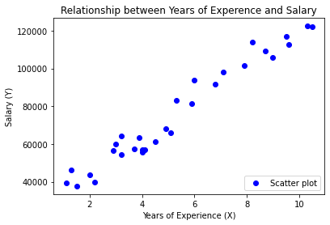

```python
import matplotlib.pyplot as plt
plt.scatter(x,y, color ="blue", label="Scatter plot")
plt.title("Relationship between Years of Experence and Salary")
plt.xlabel("Years of Experience (X)")
plt.ylabel("Salary (Y)")
plt.legend(loc=4)
plt.show()
```

# Train test split

split the dataset into two sets namely - train set and test set.

The model learn the relationships from the training data and predict on test data.

here test size is 0.2 i.e we only using 20% of data from set

```python
from sklearn.model_selection import train_test_split
x_train,x_test,y_train,y_test=train_test_split(x,y,test_size=0.2,random_state=0)
```

```python
print(x_train.shape)
print(y_train.shape)
print(x_test.shape)
print(y_test.shape)
```

```
(24, 1)
(24, 1)
(6, 1)
(6, 1)
```

```python
y_test
```

```
array([[ 37731.],
       [122391.],
       [ 57081.],
       [ 63218.],
       [116969.],
       [109431.]])
```

```python
x_test
```

```
array([[ 1.5],
       [10.3],
       [ 4.1],
       [ 3.9],
       [ 9.5],
       [ 8.7]])
```

# Mechanics of the model

I split the dataset into two sets – the training set and the test set. Then, I instantiate the regressor lm and fit it on the training set with the fit method.

In this step, the model learned the relationships between the training data (X_train, y_train).

Now the model is ready to make predictions on the test data (X_test). Hence, I predict on the test data using the predict method

```python
from sklearn.linear_model import LinearRegression
lm=LinearRegression()
lm.fit(x_train,y_train)
y_pred=lm.predict(x_test)
y_pred
```

```
array([[ 40748.96184072],
       [122699.62295594],
       [ 64961.65717022],
       [ 63099.14214487],
       [115249.56285456],
       [107799.50275317]])
```

**In next step i am predicting salary of a first 5 values from year experience data**

logic for that lm.predict(x)[0:5]

we used simple slicing method for that if we don't use that it will predict values for all dataset we don't want that

```python
lm.predict(x)[0:5]
```

```
array([[37023.93179003],
       [38886.44681538],
       [40748.96184072],
       [45405.24940409],
       [47267.76442943]])
```

# Regression metrics for model performance

Now, it is the time to evaluate model performance.

For regression problems, there are two ways to compute the model performance. They are RMSE (Root Mean Square Error) and R-Squared Value. These are explained below

# RMSE

RMSE is the standard deviation of the residuals.

=>So, RMSE gives us the standard deviation of the unexplained variance by the model.

=>It can be calculated by taking square root of Mean Squared Error. RMSE is an absolute measure of fit.

=>It gives us how spread the residuals are, given by the standard deviation of the residuals.

=>The more concentrated the data is around the regression line, the lower the residuals and hence lower the standard deviation of residuals.

=>It results in lower values of RMSE.

=>So, lower values of RMSE indicate better fit of data

# Calculating the RMSE

**Formula- RMSE=(mse)*0.5 ................. i.e Square root od mse**

```
       mse= mean Squared Error

       mse=1/n∑((ytest-ypred)^2)
```

According to formula we need square of (ytest-ypred) to we define the logic to find that and create array of it.

we need ∑(ytest-ypred) so we use inbuilt function called sum() to solve that and store the resultin 'Sumation'

then according to formula we got Mean Squared Error

```python
ytest_yPred=[y_test[i]-y_pred[i] for i in range(0,(len(y_pred)))]
ytest_ypred=[i**2 for i in ytest_yPred]
print(ytest_ypred)
Sumation=sum(ytest_ypred)
mse=Sumation/(len(ytest_ypred))
print(mse)
```

```
[array([9108093.67205393]), array([95248.12893241]), array([62104757.43450598]), array([14127.18972563]), array([2956464.09713445]), array([2661783.26640697])]
[12823412.29812656]
```

# RMSE value

According to formula i.e RMSE= (mse)^0.5

We got,

```python
#RMSE
rmse=mse**0.5
print("RMSE value:{}".format(rmse))
```

```
RMSE value:[3580.97923732]
```

```python
print(y_test)
print(y_pred)
```

```
[[ 37731.]
 [122391.]
 [ 57081.]
 [ 63218.]
 [116969.]
 [109431.]]
[[ 40748.96184072]
 [122699.62295594]
 [ 64961.65717022]
 [ 63099.14214487]
 [115249.56285456]
 [107799.50275317]]
```